# CLUSTER ANALYSIS

SOFTANBEES TECHNOLOGIES PVT. LTD.

# **Basic idea about Cluster Analysis**

# **1. Introduction**

- **What is Clustering?**  
  Clustering is the classification of data objects into similarity groups (clusters) according to a defined distance measure. It is used in many fields, such as machine learning, data mining, pattern recognition, image analysis, genomics, systems biology, etc. Machine learning typically regards data clustering as a form of unsupervised learning.
- **Why Clustering in R?**
1. Efficient data structures and functions for clustering
2. Reproducible and programmable
3. Comprehensive set of clustering and machine learning libraries
4. Integration with many other data analysis tools
- **What is the purpose of clustering?**

The members of a cluster are more like each other than they are like members of other clusters. The goal of clustering analysis is to find high-quality clusters such that the inter-cluster similarity is low and the intra-cluster similarity is high. Clustering, like classification, is used to segment the data.

**What is the goal of clustering?**

The goal of clustering is to identify distinct groups in a dataset. Assessment and pruning of hierarchical model-based clustering. The goal of clustering is to identify distinct groups in a dataset.

## Types of clustering algorithms

Since the task of clustering is subjective, the means that can be used for achieving this goal are plenty. Every methodology follows a different set of rules for defining the ‘similarity’ among data points. In fact, there are more than 100 clustering algorithms known. But few of the algorithms are used popularly, let’s look at them in detail:

- **Connectivity models:** As the name suggests, these models are based on the notion that the data points closer in data space exhibit more similarity to each other than the data points lying farther away. These models can follow two approaches. In the first approach, they start with classifying all data points into separate clusters & then aggregating them as the distance decreases. In the second approach, all data points are classified as a single cluster and then partitioned as the distance increases. Also, the choice of distance function is subjective. These models are very easy to interpret but lacks scalability for handling big datasets. Examples of these models are hierarchical clustering algorithm and its variants.
- **Centroid models:** These are iterative clustering algorithms in which the notion of similarity is derived by the closeness of a data point to the centroid of the clusters. K-Means clustering algorithm is a popular algorithm that falls into this category. In these models, the no. of clusters required at the end have to be mentioned beforehand, which makes it important to have prior knowledge of the dataset. These models run iteratively to find the local optima.
- **Distribution models:** These clustering models are based on the notion of how probable is it that all data points in the cluster belong to the same distribution (For example: Normal, Gaussian). These models often suffer from overfitting. A popular example of these models is Expectation-maximization algorithm which uses multivariate normal distributions.
- **Density Models:** These models search the data space for areas of varied density of data points in the data space. It isolates various different density regions and assign the data points within these regions in the same cluster. Popular examples of density models are DBSCAN and OPTICS.

## Applications of Clustering

Clustering has a large no. of applications spread across various domains. Some of the most popular applications of clustering are:

i.Recommendation engines

2. Market segmentation
3. Social network analysis
4. Search result grouping
5. Medical imaging
6. Image segmentation
7. Anomaly detection

# **2. Data Preprocessing**

## 2.1 Data Transformations

Choice depends on data set!  
- Center and standardize

1. Center: subtract from each value the mean of the corresponding vector
2. Standardize: devide by standard deviation

**Result:** Mean = 0 and STDEV = 1

- Center and scale with the scale() function
1. Center: subtract from each value the mean of the corresponding vector
2. Scale: divide centered vector by their root mean square (rms):

$$\begin{align}
x_{rms} = \sqrt[]{\frac{1}{n-1}\sum_{i=1}^{n}{x_{i}{^2}}}
\end{align}\$$
**Result:** Mean = 0 and STDEV = 1

- Log transformation
- Rank transformation: replace measured values by ranks
- No transformation

## 2.2 Distance Methods

List of most common ones!

- Euclidean distance for two profiles X and Y:
  $$\begin{align}
  d(X,Y) = \sqrt[]{ \sum_{i=1}^{n}{(x_{i}-y_{i})^2} }
  \end{align}\$$
  - Disadvantages: not scale invariant, not for negative correlations
- Maximum, Manhattan, Canberra, binary, Minowski, …
- Correlation-based distance: 1-r
- Pearson correlation coefficient (PCC):

$$\begin{align}
r = \frac{n\sum_{i=1}^{n}{x_{i}y_{i}} - \sum_{i=1}^{n}{x_{i}} \sum_{i=1}^{n}{y_{i}}}{ \sqrt[]{(\sum_{i=1}^{n}{x_{i}^2} - (\sum_{i=1}^{n}{x_{i})^2}) (\sum_{i=1}^{n}{y_{i}^2} - (\sum_{i=1}^{n}{y_{i})^2})} }
\end{align}\$$

- Disadvantage: outlier sensitive
- Spearman correlation coefficient (SCC)
- Same calculation as PCC but with ranked values!

There are many more distance measures

- If the distances among items are quantifiable, then clustering is possible.
- Choose the most accurate and meaningful distance measure for a given field of application.
- If uncertain then choose several distance measures and compare the results.

## 2.3 Cluster Linkage

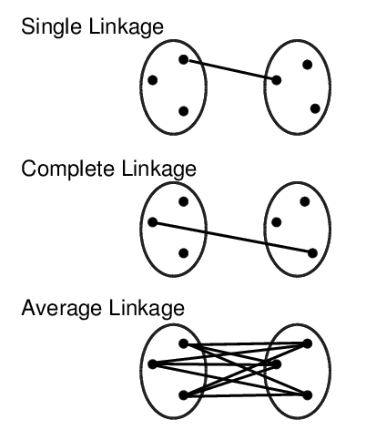